# PRA2: Limpieza y análisis de datos

Joshua Prior Avila y Marcos Caballero

Junio 2022

Se desea elaborar un proyecto analítico y usar las herramientas de integración, limpieza, validación y análisis de las mismas.

# 1 Dataset “Red Wine Quality”

## 1.1 ¿Por qué es importante? ¿Qué problema pretende responder?

Enlace al dataset de Kaggle [Red Wine Quality](https://www.kaggle.com/datasets/uciml/red-wine-quality-cortez-et-al-2009)

Se incluyen dos conjuntos de datos relacionados con muestras de vino tinto y blanco vinho verde, procedentes del norte de Portugal. El objetivo es modelar la calidad del vino a partir de pruebas fisicoquímicas.

Debido a cuestiones de privacidad y logística, sólo se dispone de variables fisicoquímicas (de entrada) y sensoriales (de salida) (por ejemplo, no hay datos sobre tipos de uva, marca de vino, precio de venta del vino, etc.). Estos conjuntos de datos pueden considerarse tareas de clasificación o de regresión. Las clases están ordenadas y no equilibradas (por ejemplo, hay muchos más vinos normales que excelentes o malos). Se podrían utilizar algoritmos de detección de valores atípicos para detectar los pocos vinos excelentes o malos. Además, no estamos seguros de que todas las variables de entrada sean relevantes. Así que podría ser interesante probar métodos de selección de características [1].

## 1.2 Descripción

Estos conjuntos de datos pueden considerarse tareas de clasificación o regresión. Las clases están ordenadas y no equilibradas (por ejemplo, hay más vinos normales que excelentes o malos). Los algoritmos de detección de valores atípicos podrían utilizarse para detectar los pocos vinos excelentes o pobres. o pobres. Además, no estamos seguros de que todas las variables de entrada sean relevantes. Así que podría ser interesante probar los métodos de selección de características.

Nota: varios de los atributos pueden estar correlacionados, por lo que tiene sentido aplicar algún tipo de selección de características.

Variables de entrada (basadas en pruebas fisicoquímicas):

1. `fixed acidity`: acidez fija –> la mayoría de los ácidos que intervienen en el vino son fijos o no volátiles (no se evaporan fácilmente).
2. `volatile acidity`: acidez volátil –> la cantidad de ácido acético en el vino, que en niveles demasiado altos puede producir un sabor desagradable a vinagre.
3. `citric acid`: ácido cítrico –> en pequeñas cantidades, el ácido cítrico puede aportar “frescura” y sabor a los vinos.
4. `residual sugar`: azúcar residual –> la cantidad de azúcar que queda después de la fermentación; es raro encontrar vinos con menos de 1 gramo/litro.
5. `chlorides`: cloruros –> la cantidad de sal en el vino.
6. `free sulfur dioxide`: dióxido de azufre libre –> la forma libre de SO2 existe en equilibrio entre el SO2 molecular (como gas disuelto) y el ion bisulfito.
7. `total sulfur dioxide`: dióxido de azufre total –> la cantidad de formas libres y ligadas de S02; en bajas concentraciones, el SO2 es casi indetectable en el vino.
8. `density`: densidad –> la densidad se aproxima a la del agua en función del porcentaje de alcohol y del contenido de azúcar.
9. `pH`: pH –> describe el grado de acidez o base de un vino en una escala de 0 (muy ácido) a 14 (muy básico); la mayoría de los vinos se sitúan entre 3 y 4 grados.
10. `sulphates`: sulfatos –> un aditivo del vino que puede contribuir a los niveles de gas de dióxido de azufre (S02), que actúa como antimicrobiano.
11. `alcohol`: el porcentaje de alcohol del vino.

Variable de salida (basada en datos sensoriales):

12. `quality`: calidad –> basada en datos sensoriales, puntuación entre 0 y 10.

# 2 Pasos previos a la resolución del problema

Instalamos y cargamos las librerías necesarias:

```r
if (!require('ggplot2')) install.packages('ggplot2'); library('ggplot2')
if (!require('corrplot')) install.packages('dplyr'); library('corrplot')
if (!require('randomForest')) install.packages('randomForest'); library('randomForest')
if (!require('ggthemes')) install.packages('ggthemes'); library('ggthemes')
if (!require('reshape2')) install.packages('reshape2'); library('reshape2')
if (!require('dplyr')) install.packages('dplyr'); library('dplyr')
if (!require('car')) install.packages('car'); library('car')
if (!require('writexl')) install.packages('writexl'); library('writexl')
```

Cargamos el fichero de datos:

```r
wines <- read.csv('winequality-red.csv',stringsAsFactors = FALSE)
```

# 3 Integración y selección de los datos de interés a analizar

```r
wines$good.wine<-ifelse(wines$quality>6,1,0) # Variable que indique si un vino es bueno o malo
str(wines)
```

```
## 'data.frame':    1599 obs. of  13 variables:
##  $ fixed.acidity       : num  7.4 7.8 7.8 11.2 7.4 7.4 7.9 7.3 7.8 7.5 ...
##  $ volatile.acidity    : num  0.7 0.88 0.76 0.28 0.7 0.66 0.6 0.65 0.58 0.5 ...
##  $ citric.acid         : num  0 0 0.04 0.56 0 0 0.06 0 0.02 0.36 ...
##  $ residual.sugar      : num  1.9 2.6 2.3 1.9 1.9 1.8 1.6 1.2 2 6.1 ...
##  $ chlorides           : num  0.076 0.098 0.092 0.075 0.076 0.075 0.069 0.065 0.073 0.071 ...
##  $ free.sulfur.dioxide : num  11 25 15 17 11 13 15 15 9 17 ...
##  $ total.sulfur.dioxide: num  34 67 54 60 34 40 59 21 18 102 ...
##  $ density             : num  0.998 0.997 0.997 0.998 0.998 ...
##  $ pH                  : num  3.51 3.2 3.26 3.16 3.51 3.51 3.3 3.39 3.36 3.35 ...
##  $ sulphates           : num  0.56 0.68 0.65 0.58 0.56 0.56 0.46 0.47 0.57 0.8 ...
##  $ alcohol             : num  9.4 9.8 9.8 9.8 9.4 9.4 9.4 10 9.5 10.5 ...
##  $ quality             : int  5 5 5 6 5 5 5 7 7 5 ...
##  $ good.wine           : num  0 0 0 0 0 0 0 1 1 0 ...
```

Vemos que tenemos 1599 registros y 13 variables que los caracterizan.

```r
summary(wines)
```

```
##  fixed.acidity   volatile.acidity  citric.acid    residual.sugar
##  Min.   : 4.60   Min.   :0.1200   Min.   :0.000   Min.   : 0.900
##  1st Qu.: 7.10   1st Qu.:0.3900   1st Qu.:0.090   1st Qu.: 1.900
##  Median : 7.90   Median :0.5200   Median :0.260   Median : 2.200
##  Mean   : 8.32   Mean   :0.5278   Mean   :0.271   Mean   : 2.539
##  3rd Qu.: 9.20   3rd Qu.:0.6400   3rd Qu.:0.420   3rd Qu.: 2.600
##  Max.   :15.90   Max.   :1.5800   Max.   :1.000   Max.   :15.500
##    chlorides       free.sulfur.dioxide total.sulfur.dioxide    density
##  Min.   :0.01200   Min.   : 1.00       Min.   :  6.00       Min.   :0.9901
##  1st Qu.:0.07000   1st Qu.: 7.00       1st Qu.: 22.00       1st Qu.:0.9956
##  Median :0.07900   Median :14.00       Median : 38.00       Median :0.9968
##  Mean   :0.08747   Mean   :15.87       Mean   : 46.47       Mean   :0.9967
##  3rd Qu.:0.09000   3rd Qu.:21.00       3rd Qu.: 62.00       3rd Qu.:0.9978
##  Max.   :0.61100   Max.   :72.00       Max.   :289.00       Max.   :1.0037
##        pH          sulphates         alcohol         quality
##  Min.   :2.740   Min.   :0.3300   Min.   : 8.40   Min.   :3.000
##  1st Qu.:3.210   1st Qu.:0.5500   1st Qu.: 9.50   1st Qu.:5.000
##  Median :3.310   Median :0.6200   Median :10.20   Median :6.000
##  Mean   :3.311   Mean   :0.6581   Mean   :10.42   Mean   :5.636
##  3rd Qu.:3.400   3rd Qu.:0.7300   3rd Qu.:11.10   3rd Qu.:6.000
##  Max.   :4.010   Max.   :2.0000   Max.   :14.90   Max.   :8.000
##    good.wine
##  Min.   :0.0000
##  1st Qu.:0.0000
##  Median :0.0000
##  Mean   :0.1357
##  3rd Qu.:0.0000
##  Max.   :1.0000
```

Estas son las estadísticas básicas. A continuación revisamos la relación la relación entre las propiedades fisicoquímicas y el hecho de que un vino sea bueno o no (su calidad) para conocer mejor los datos:

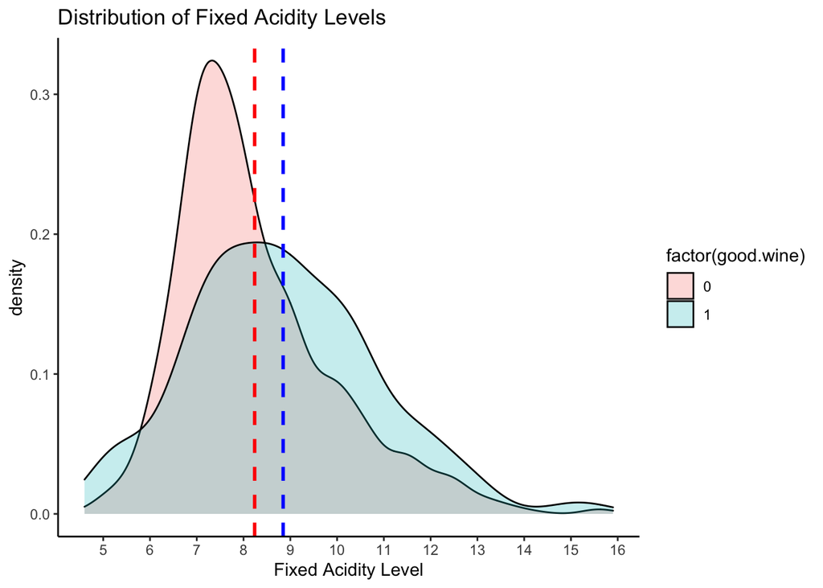

```r
#Fixed Acidity and Wine Quality
ggplot(wines,aes(x=fixed.acidity,fill=factor(good.wine)))+geom_density(alpha=0.25)+
  geom_vline(aes(xintercept=mean(fixed.acidity[good.wine==0],na.rm=T)),color="red",linetype="dashed",lwd=1)+
  geom_vline(aes(xintercept=mean(fixed.acidity[good.wine==1],na.rm=T)),color="blue",linetype="dashed",lwd=1)+
  scale_x_continuous(breaks = seq(4,16,1))+
  xlab(label = "Fixed Acidity Level")+
  ggtitle("Distribution of Fixed Acidity Levels")+
  theme_classic()
```

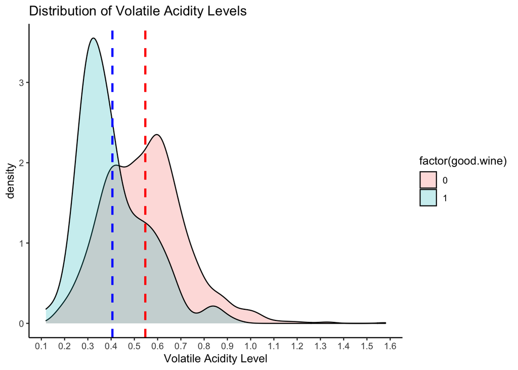

```r
#Volatile Acidity and Wine Quality
ggplot(wines,aes(x=volatile.acidity,fill=factor(good.wine)))+geom_density(alpha=0.25)+
  geom_vline(aes(xintercept=mean(volatile.acidity[good.wine==0],na.rm=T)),color="red",linetype="dashed",lwd=1)+
  geom_vline(aes(xintercept=mean(volatile.acidity[good.wine==1],na.rm=T)),color="blue",linetype="dashed",lwd=1)+
  scale_x_continuous(breaks = seq(0,1.6,0.1))+
  xlab(label = "Volatile Acidity Level")+
  ggtitle("Distribution of Volatile Acidity Levels")+
  theme_classic()
```

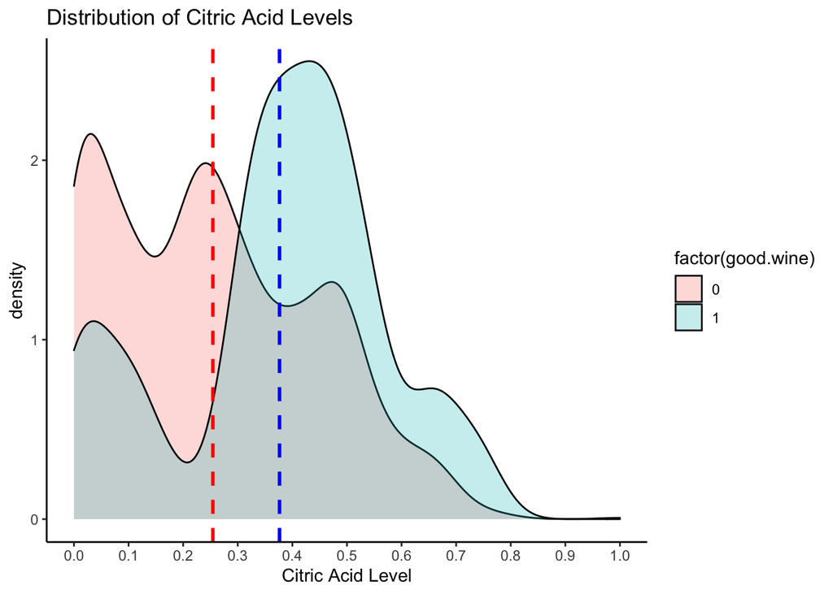

```r
#Citric Acid and Wine Quality
ggplot(wines,aes(x=citric.acid,fill=factor(good.wine)))+geom_density(alpha=0.25)+
  geom_vline(aes(xintercept=mean(citric.acid[good.wine==0],na.rm=T)),color="red",linetype="dashed",lwd=1)+
  geom_vline(aes(xintercept=mean(citric.acid[good.wine==1],na.rm=T)),color="blue",linetype="dashed",lwd=1)+
  scale_x_continuous(breaks = seq(0,1,0.1))+
  xlab(label = "Citric Acid Level")+
  ggtitle("Distribution of Citric Acid Levels")+
  theme_classic()
```

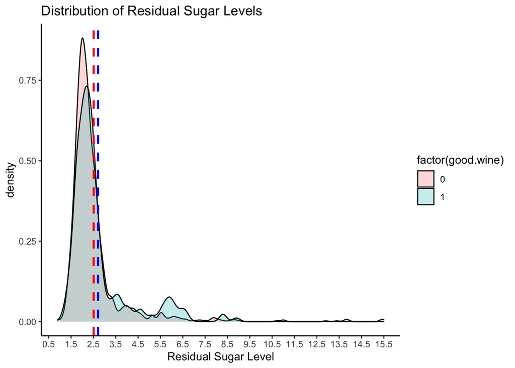

```r
#Residual Sugar and Wine Quality
ggplot(wines,aes(x=residual.sugar,fill=factor(good.wine)))+geom_density(alpha=0.25)+
  geom_vline(aes(xintercept=mean(residual.sugar[good.wine==0],na.rm=T)),color="red",linetype="dashed",lwd=1)+
  geom_vline(aes(xintercept=mean(residual.sugar[good.wine==1],na.rm=T)),color="blue",linetype="dashed",lwd=1)+
  scale_x_continuous(breaks = seq(0.5,15.5,1))+
  xlab(label = "Residual Sugar Level")+
  ggtitle("Distribution of Residual Sugar Levels")+
  theme_classic()
```

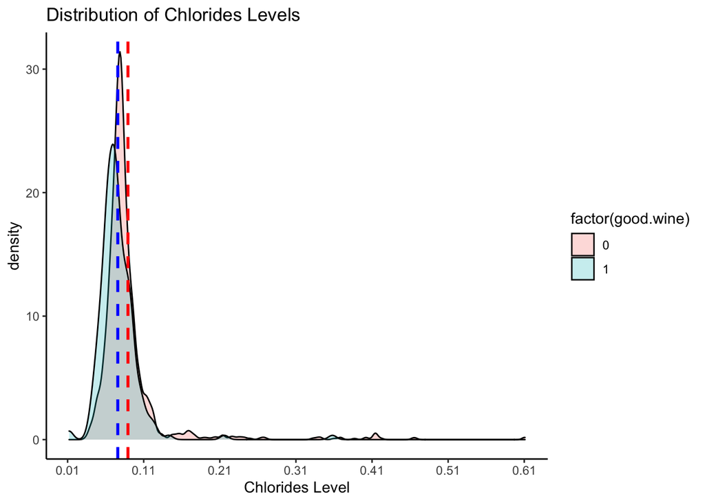

```r
#Chlorides and Wine Quality
ggplot(wines,aes(x=chlorides,fill=factor(good.wine)))+geom_density(alpha=0.25)+
  geom_vline(aes(xintercept=mean(chlorides[good.wine==0],na.rm=T)),color="red",linetype="dashed",lwd=1)+
  geom_vline(aes(xintercept=mean(chlorides[good.wine==1],na.rm=T)),color="blue",linetype="dashed",lwd=1)+
  scale_x_continuous(breaks = seq(0.01,0.62,0.1))+
  xlab(label = "Chlorides Level")+
  ggtitle("Distribution of Chlorides Levels")+
  theme_classic()
```

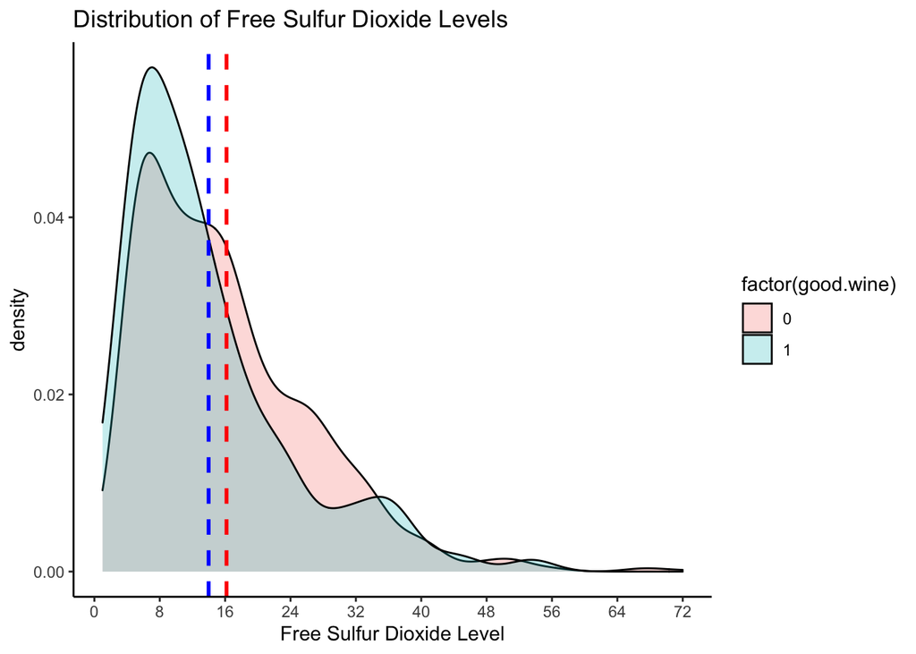

```r
#Free Sulfur Dioxide and Wine Quality
ggplot(wines,aes(x=free.sulfur.dioxide,fill=factor(good.wine)))+geom_density(alpha=0.25)+
  geom_vline(aes(xintercept=mean(free.sulfur.dioxide[good.wine==0],na.rm=T)),color="red",linetype="dashed",lwd=1)+
  geom_vline(aes(xintercept=mean(free.sulfur.dioxide[good.wine==1],na.rm=T)),color="blue",linetype="dashed",lwd=1)+
  scale_x_continuous(breaks = seq(0,72,8))+
  xlab(label = "Free Sulfur Dioxide Level")+
  ggtitle("Distribution of Free Sulfur Dioxide Levels")+
  theme_classic()
```

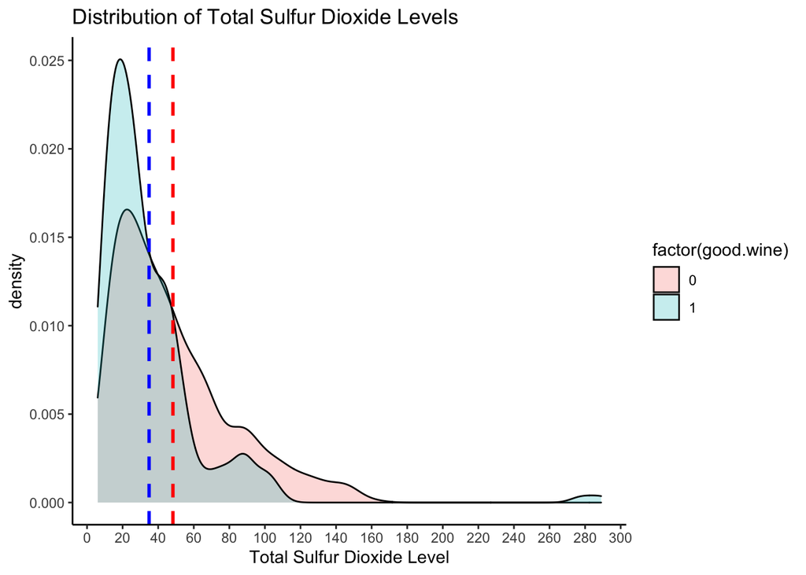

```r
#Total Sulfur Dioxide and Wine Quality
ggplot(wines,aes(x=total.sulfur.dioxide,fill=factor(good.wine)))+geom_density(alpha=0.25)+
  geom_vline(aes(xintercept=mean(total.sulfur.dioxide[good.wine==0],na.rm=T)),color="red",linetype="dashed",lwd=1)+
  geom_vline(aes(xintercept=mean(total.sulfur.dioxide[good.wine==1],na.rm=T)),color="blue",linetype="dashed",lwd=1)+
  scale_x_continuous(breaks = seq(0,300,20))+
  xlab(label = "Total Sulfur Dioxide Level")+
  ggtitle("Distribution of Total Sulfur Dioxide Levels")+
  theme_classic()
```

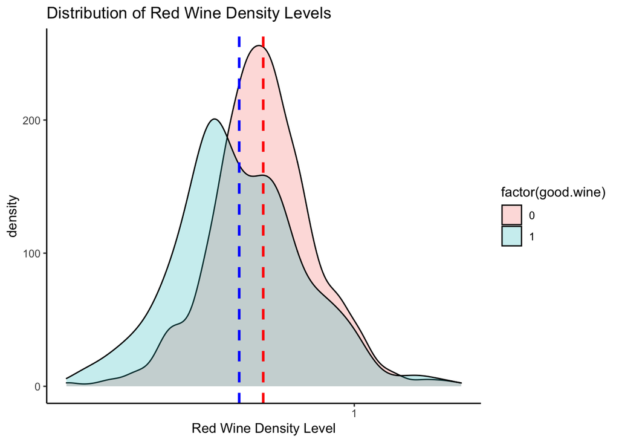

```r
#Density and Wine Quality
ggplot(wines,aes(x=density,fill=factor(good.wine)))+geom_density(alpha=0.25)+
  geom_vline(aes(xintercept=mean(density[good.wine==0],na.rm=T)),color="red",linetype="dashed",lwd=1)+
  geom_vline(aes(xintercept=mean(density[good.wine==1],na.rm=T)),color="blue",linetype="dashed",lwd=1)+
  scale_x_continuous(breaks = seq(0.9,1.1,0.05))+
  xlab(label = "Red Wine Density Level")+
  ggtitle("Distribution of Red Wine Density Levels")+
  theme_classic()
```

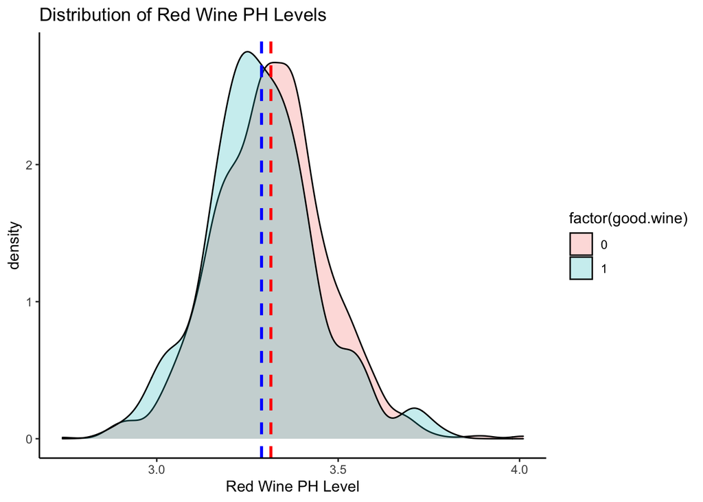

```r
#PH and Wine Quality
ggplot(wines,aes(x=pH,fill=factor(good.wine)))+geom_density(alpha=0.25)+
  geom_vline(aes(xintercept=mean(pH[good.wine==0],na.rm=T)),color="red",linetype="dashed",lwd=1)+
  geom_vline(aes(xintercept=mean(pH[good.wine==1],na.rm=T)),color="blue",linetype="dashed",lwd=1)+
  scale_x_continuous(breaks = seq(2.5,5,0.5))+
  xlab(label = "Red Wine PH Level")+
  ggtitle("Distribution of Red Wine PH Levels")+
  theme_classic()
```

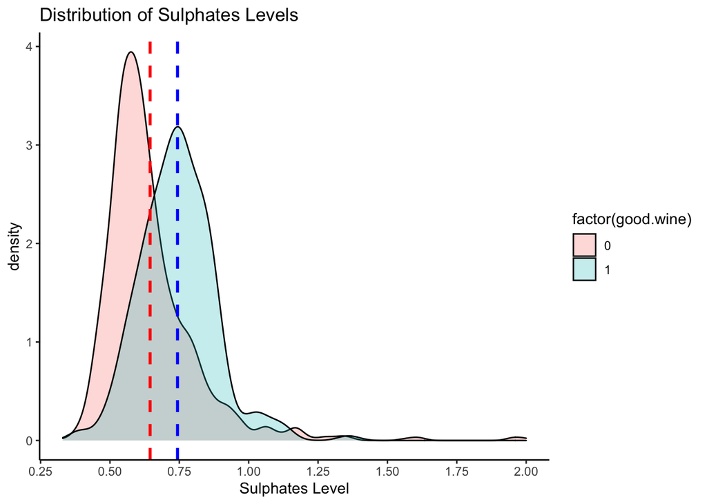

```r
#Sulphates and Wine Quality
ggplot(wines,aes(x=sulphates,fill=factor(good.wine)))+geom_density(alpha=0.25)+
  geom_vline(aes(xintercept=mean(sulphates[good.wine==0],na.rm=T)),color="red",linetype="dashed",lwd=1)+
  geom_vline(aes(xintercept=mean(sulphates[good.wine==1],na.rm=T)),color="blue",linetype="dashed",lwd=1)+
  scale_x_continuous(breaks = seq(0,2,0.25))+
  xlab(label = "Sulphates Level")+
  ggtitle("Distribution of Sulphates Levels")+
  theme_classic()
```

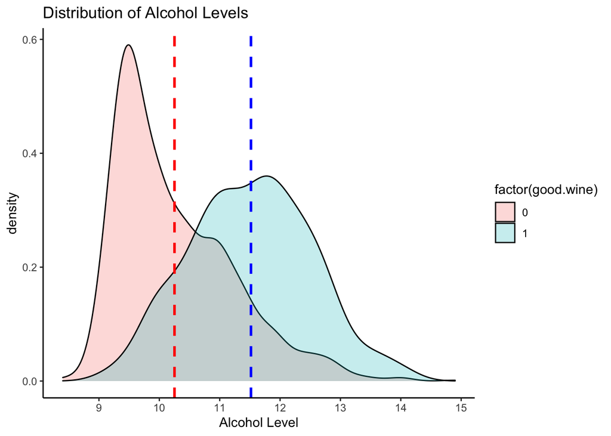

```r
#Alcohol and Wine Quality
ggplot(wines,aes(x=alcohol,fill=factor(good.wine)))+geom_density(alpha=0.25)+
  geom_vline(aes(xintercept=mean(alcohol[good.wine==0],na.rm=T)),color="red",linetype="dashed",lwd=1)+
  geom_vline(aes(xintercept=mean(alcohol[good.wine==1],na.rm=T)),color="blue",linetype="dashed",lwd=1)+
  scale_x_continuous(breaks = seq(8,15,1))+
  xlab(label = "Alcohol Level")+
  ggtitle("Distribution of Alcohol Levels")+
  theme_classic()
```

Los gráficos exploratorios muestran que los vinos buenos y malos tienen una distribución muy similar de sus correspondientes propiedades fisicoquímicas. Los atributos más discriminantes que podemos observar son los sulfatos y el nivel de alcohol del vino.

Intentamos predecir la calidad del vino, por lo que nos interesan las dos últimas columnas/filas para saber cuál de las variables tiene una mayor relación con la calidad del vino. Como sugiere el mapa de calor, el alcohol tiene la mayor correlación con la calidad del vino.

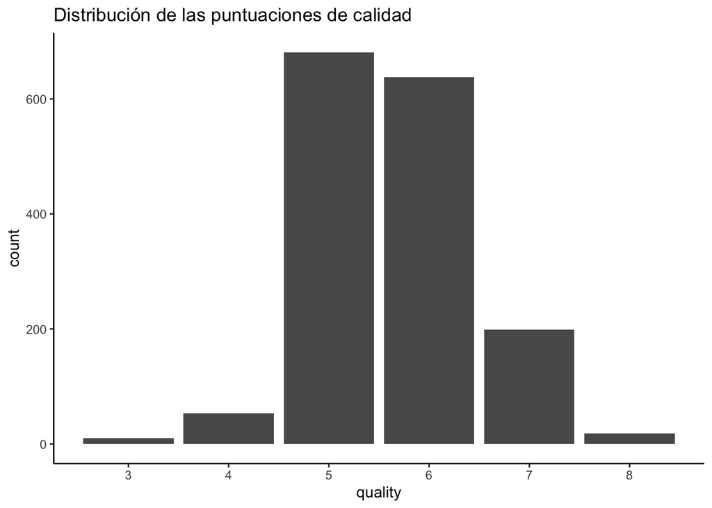

```r
ggplot(wines,aes(x=quality))+geom_bar(stat = "count",position = "dodge")+
  scale_x_continuous(breaks = seq(3,8,1))+
  ggtitle("Distribución de las puntuaciones de calidad")+
  theme_classic()
```

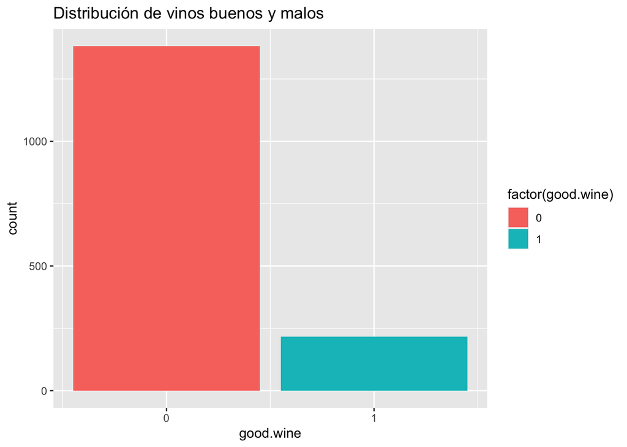

```r
ggplot(wines,aes(x=good.wine,fill=factor(good.wine)))+geom_bar(stat = "count",position = "dodge")+
  scale_x_continuous(breaks = seq(0,1,1))+
  ggtitle("Distribución de vinos buenos y malos")
```

El gráfico de arriba muestra lo que ya habíamos deducido anteriormente, que los buenos vinos fueron superados por los malos por un amplio margen. La mayoría de los vinos eran mediocres (con una calificación de 5 o 6), pero también pudimos ver que hay algunos vinos malos (3 o 4). La gran mayoría de los buenos vinos tiene una calificación de calidad de 7.

# 4 Limpieza de los datos

## 4.1 Valores nulos, vacíos o 0

```r
colSums(is.na(wines))
```

```
##        fixed.acidity     volatile.acidity          citric.acid
##                    0                    0                    0
##       residual.sugar            chlorides  free.sulfur.dioxide
##                    0                    0                    0
## total.sulfur.dioxide              density                   pH
##                    0                    0                    0
##            sulphates              alcohol              quality
##                    0                    0                    0
##            good.wine
##                    0
```

```r
colSums(wines=="")
```

```
##        fixed.acidity     volatile.acidity          citric.acid
##                    0                    0                    0
##       residual.sugar            chlorides  free.sulfur.dioxide
##                    0                    0                    0
## total.sulfur.dioxide              density                   pH
##                    0                    0                    0
##            sulphates              alcohol              quality
##                    0                    0                    0
##            good.wine
##                    0
```

```r
colSums(wines == 0)
```

```
##        fixed.acidity     volatile.acidity          citric.acid
##                    0                    0                  132
##       residual.sugar            chlorides  free.sulfur.dioxide
##                    0                    0                    0
## total.sulfur.dioxide              density                   pH
##                    0                    0                    0
##            sulphates              alcohol              quality
##                    0                    0                    0
##            good.wine
##                 1382
```

```r
sum(wines$citric.acid == 0)
```

```
## [1] 132
```

Únicamente encontrmos 0s en el ácido cítrico. Pero no debemos realizar ninguna actuación, ya que es un valor normal para dicho atributo. Por lo tanto, no existen datos perdidos.

## 4.2 Valores extremos

Comprobamos si existen valores extremos a través de los boxplot de cada columna:

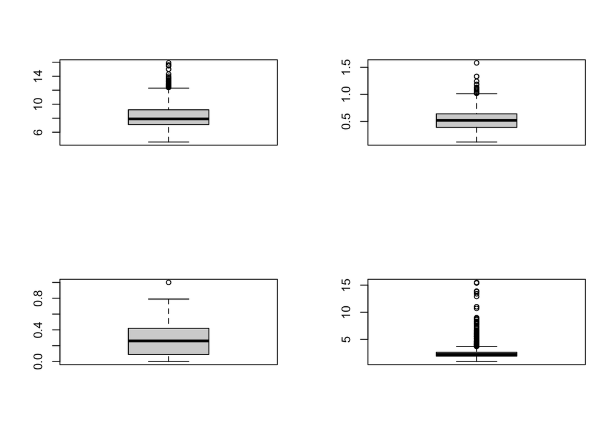

```r
par(mfrow=c(2,2))
boxplot(wines$fixed.acidity)
boxplot(wines$volatile.acidity)
boxplot(wines$citric.acid)
boxplot(wines$residual.sugar)
```

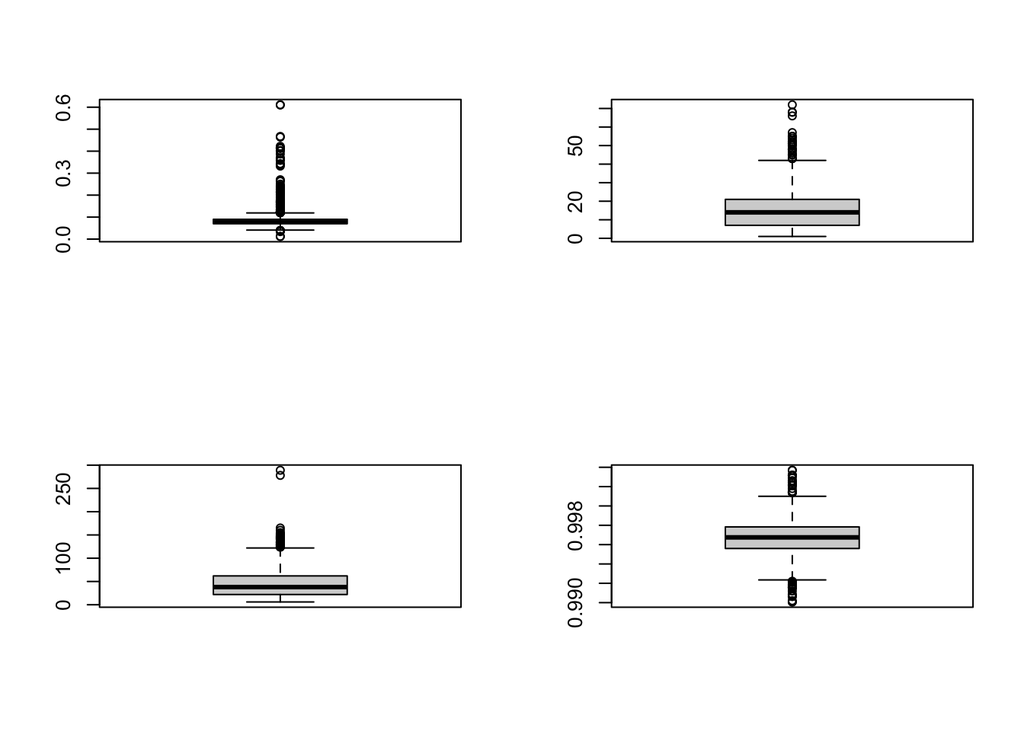

```r
boxplot(wines$chlorides)
boxplot(wines$free.sulfur.dioxide)
boxplot(wines$total.sulfur.dioxide)
boxplot(wines$density)
```

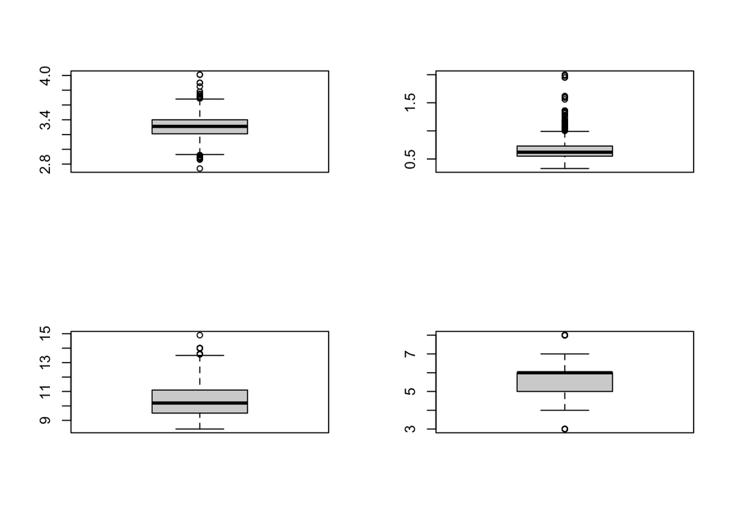

```r
boxplot(wines$pH)
boxplot(wines$sulphates)
boxplot(wines$alcohol)
boxplot(wines$quality)
```

Revisamos el atributo **calidad** de los valores que son outliers para cada columna:

```r
prop.table(table(wines$quality))*100
```

```
##
##          3          4          5          6          7          8
##  0.6253909  3.3145716 42.5891182 39.8999375 12.4452783  1.1257036
```

```r
table(wines$quality[which(wines$fixed.acidity %in% c(boxplot.stats(wines$fixed.acidity)$out))])
```

```
##
##  4  5  6  7  8
##  1 15 22 10  1
```

```r
table(wines$quality[which(wines$volatile.acidity %in% c(boxplot.stats(wines$volatile.acidity)$out))])
```

```
##
## 3 4 5 6
## 3 6 8 2
```

```r
table(wines$quality[which(wines$citric.acid %in% c(boxplot.stats(wines$citric.acid)$out))])
```

```
##
## 4
## 1
```

```r
table(wines$quality[which(wines$residual.sugar %in% c(boxplot.stats(wines$residual.sugar)$out))])
```

```
##
##  3  4  5  6  7  8
##  2  9 66 47 29  2
```

```r
table(wines$quality[which(wines$chlorides %in% c(boxplot.stats(wines$chlorides)$out))])
```

```
##
##  3  4  5  6  7
##  4  4 50 44 10
```

```r
table(wines$quality[which(wines$free.sulfur.dioxide %in% c(boxplot.stats(wines$free.sulfur.dioxide)$out))])
```

```
##
##  5  6  7
## 18  8  4
```

```r
table(wines$quality[which(wines$total.sulfur.dioxide %in% c(boxplot.stats(wines$total.sulfur.dioxide)$out))])
```

```
##
##  5  6  7
## 47  6  2
```

```r
table(wines$quality[which(wines$density %in% c(boxplot.stats(wines$density)$out))])
```

```
##
##  5  6  7  8
##  9 24 10  2
```

```r
table(wines$quality[which(wines$pH %in% c(boxplot.stats(wines$pH)$out))])
```

```
##
##  4  5  6  7  8
##  3 11 14  5  2
```

```r
table(wines$quality[which(wines$sulphates %in% c(boxplot.stats(wines$sulphates)$out))])
```

```
##
##  4  5  6  7  8
##  3 29 17  9  1
```

```r
table(wines$quality[which(wines$alcohol %in% c(boxplot.stats(wines$alcohol)$out))])
```

```
##
## 5 6 7 8
## 1 5 5 2
```

Cantidad de outliers por calidad del vino:

- **Calidad 3**: 9 - 1.5%
- **Calidad 4**: 27 - 4.7%
- **Calidad 5**: 254 - 44.3%
- **Calidad 6**: 189 - 32.9%
- **Calidad 7**: 84 - 14.6%
- **Calidad 8**: 10 - 1.7%

Encontramos un total de **573 outliers** contando muestras repetidas. Además, podemos comprobar que se distribuyen muy similar a la distribución de la calidad. Por ello, **decidimos no eliminarlos** y seguir con el análisis teniendo en cuenta que es habitual encontrar outliers que pertenezcan a valores dentro de los estándares de los atributos del vino.

# 5 Análisis de los datos

## 5.1 Selección de los grupos de datos que se quieren analizar/comparar (p. e., si se van a comparar grupos de datos, ¿cuáles son estos grupos y qué tipo de análisis se van a aplicar?)

Se pretende analizar qué atributos son más determinantes en la calidad del vino. Para ello, usaremos regresiones que sean capaces de indicarnos cuáles son.

Además, analizaremos los atributos más importantes para indicar que el vino es de buena calidad.

## 5.2 Comprobación de la normalidad y homogeneidad de la varianza.

Comprobamos si se cumplen para cada una de los atributos de los que disponemos [2]:

- Para la **normalidad**:

```r
for(i in 1:ncol(wines)) {
  print(paste0("El atributo analizado es ", names(wines)[i]))
  print(ks.test(wines[, i], pnorm, mean(wines[, i]), sd(wines[, i])))
  print(shapiro.test(wines[, i]))
}
```

```
## [1] "El atributo analizado es fixed.acidity"
##
##  One-sample Kolmogorov-Smirnov test
##
## data:  wines[, i]
## D = 0.1105, p-value < 2.2e-16
## alternative hypothesis: two-sided
##
##
##  Shapiro-Wilk normality test
##
## data:  wines[, i]
## W = 0.94203, p-value < 2.2e-16
##
## [1] "El atributo analizado es volatile.acidity"
##
##  One-sample Kolmogorov-Smirnov test
##
## data:  wines[, i]
## D = 0.054662, p-value = 0.0001416
## alternative hypothesis: two-sided
##
##
##  Shapiro-Wilk normality test
##
## data:  wines[, i]
## W = 0.97434, p-value = 2.693e-16
##
## [1] "El atributo analizado es citric.acid"
##
##  One-sample Kolmogorov-Smirnov test
##
## data:  wines[, i]
## D = 0.083866, p-value = 3.407e-10
## alternative hypothesis: two-sided
##
##
##  Shapiro-Wilk normality test
##
## data:  wines[, i]
```

[output cut: 126 more lines]

```
## W = 0.85759, p-value < 2.2e-16
##
## [1] "El atributo analizado es good.wine"
##
##  One-sample Kolmogorov-Smirnov test
##
## data:  wines[, i]
## D = 0.51829, p-value < 2.2e-16
## alternative hypothesis: two-sided
##
##
##  Shapiro-Wilk normality test
##
## data:  wines[, i]
## W = 0.40472, p-value < 2.2e-16
```

Todos los valores están por debajo de 0.05, por lo que la hipótesis nula es rechazada y concluimos que ninguno de los datos cuenta con distribución normal. De todas maneras, por la cantidad de muestras del conjunto de datos, podríamos usar el teorema central del límite para aproximar la distribución de la media a una distribución normal.

- Para la **homogeneidad**:

No hay normalidad en ningún atributo, así que usamos el test de Fligner-Killeen. Para usarlo, compararemos la homogeneidad de todos los atributos con la calidad:

```r
for(i in 1:(ncol(wines)-2)) {
  print(paste0("El atributo comparado con la calidad es ", names(wines)[i]))
  print(fligner.test(wines$quality ~ wines[, i], wines))
}
```

```
## [1] "El atributo comparado con la calidad es fixed.acidity"
##
##  Fligner-Killeen test of homogeneity of variances
##
## data:  wines$quality by wines[, i]
## Fligner-Killeen:med chi-squared = 68.457, df = 95, p-value = 0.9818
##
## [1] "El atributo comparado con la calidad es volatile.acidity"
##
##  Fligner-Killeen test of homogeneity of variances
##
## data:  wines$quality by wines[, i]
## Fligner-Killeen:med chi-squared = 147.35, df = 142, p-value = 0.3621
##
## [1] "El atributo comparado con la calidad es citric.acid"
##
##  Fligner-Killeen test of homogeneity of variances
##
## data:  wines$quality by wines[, i]
## Fligner-Killeen:med chi-squared = 87.67, df = 79, p-value = 0.2362
##
## [1] "El atributo comparado con la calidad es residual.sugar"
##
##  Fligner-Killeen test of homogeneity of variances
##
## data:  wines$quality by wines[, i]
## Fligner-Killeen:med chi-squared = 85.881, df = 90, p-value = 0.6033
##
## [1] "El atributo comparado con la calidad es chlorides"
##
##  Fligner-Killeen test of homogeneity of variances
##
## data:  wines$quality by wines[, i]
## Fligner-Killeen:med chi-squared = 148.54, df = 152, p-value = 0.5642
##
## [1] "El atributo comparado con la calidad es free.sulfur.dioxide"
##
##  Fligner-Killeen test of homogeneity of variances
##
## data:  wines$quality by wines[, i]
```

[output cut: 21 more lines]

```
## Fligner-Killeen:med chi-squared = 86.558, df = 88, p-value = 0.5235
##
## [1] "El atributo comparado con la calidad es sulphates"
##
##  Fligner-Killeen test of homogeneity of variances
##
## data:  wines$quality by wines[, i]
## Fligner-Killeen:med chi-squared = 120.2, df = 95, p-value = 0.04138
##
## [1] "El atributo comparado con la calidad es alcohol"
##
##  Fligner-Killeen test of homogeneity of variances
##
## data:  wines$quality by wines[, i]
## Fligner-Killeen:med chi-squared = 135.98, df = 64, p-value = 4.157e-07
```

Concluímos que las columnas que no tienen homogeneidad con la calidad son:

- **total.sulfur.dioxide**
- **sulphates**
- **alcohol**

Haremos una revisión especial a posteriori de la influencia de estos 3 atributos en la calidad del vino.

## 5.3 Aplicación de pruebas estadísticas para comparar los grupos de datos. En función de los datos y el objetivo del estudio, aplicar pruebas de contraste de hipótesis, correlaciones, regresiones, etc. Aplicar al menos tres métodos de análisis diferentes.

Revisamos la correlación entre las propiedades:

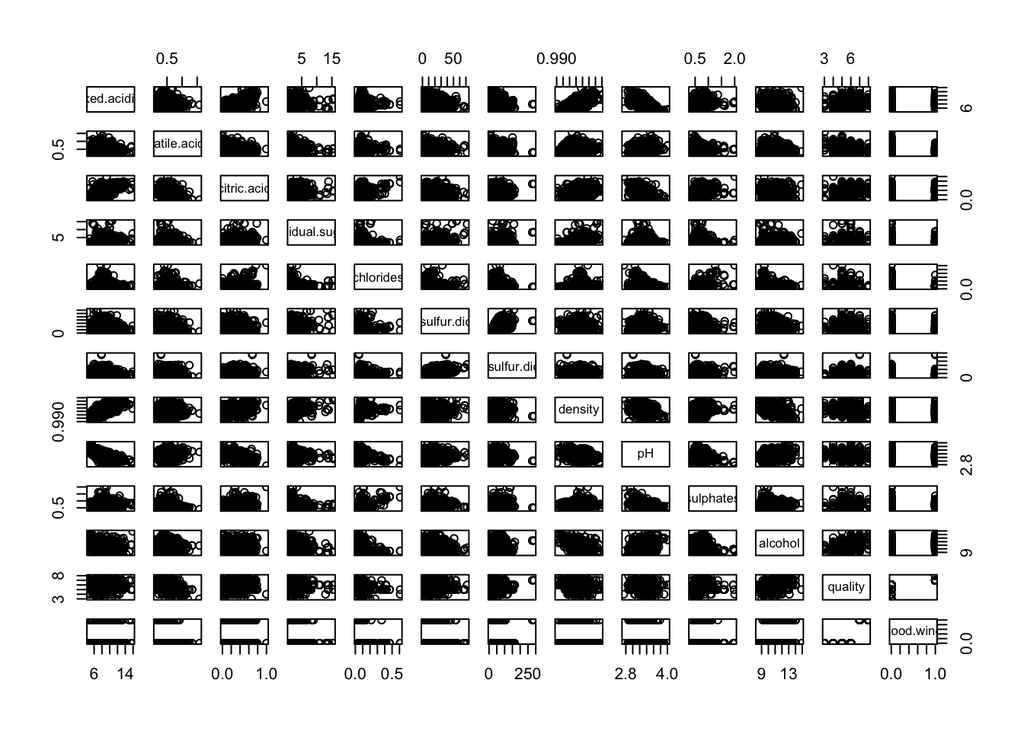

```r
plot(wines)
```

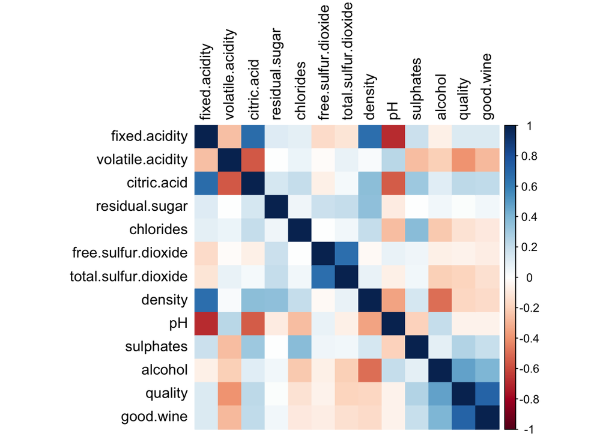

```r
corrplot(cor(wines),method='color',tl.col="black")
```

Se puede apreciar que la correlación lineal más fuerte es con el **alcohol** y con la **volatile.acidity**. En el caso del alcohol, el aumento con la calidad es proporcional. En cambio con la volatilidad de la acidez es inverso.

Para poder comprobar si son los únicos atributos que influyen en la calidad del vino, aplicamos regresión lineal que nos permitirá obtener unos resultados más precisos:

```r
modelo <- lm(quality ~ fixed.acidity + volatile.acidity + citric.acid + residual.sugar + chlorides + free.sulfur.dioxide + total.sulfur.dioxide + density + pH + sulphates + alcohol, data = wines)
summary(modelo)
```

```
##
## Call:
## lm(formula = quality ~ fixed.acidity + volatile.acidity + citric.acid +
##     residual.sugar + chlorides + free.sulfur.dioxide + total.sulfur.dioxide +
##     density + pH + sulphates + alcohol, data = wines)
##
## Residuals:
##      Min       1Q   Median       3Q      Max
## -2.68911 -0.36652 -0.04699  0.45202  2.02498
##
## Coefficients:
##                        Estimate Std. Error t value Pr(>|t|)
## (Intercept)           2.197e+01  2.119e+01   1.036   0.3002
## fixed.acidity         2.499e-02  2.595e-02   0.963   0.3357
## volatile.acidity     -1.084e+00  1.211e-01  -8.948  < 2e-16 ***
## citric.acid          -1.826e-01  1.472e-01  -1.240   0.2150
## residual.sugar        1.633e-02  1.500e-02   1.089   0.2765
## chlorides            -1.874e+00  4.193e-01  -4.470 8.37e-06 ***
## free.sulfur.dioxide   4.361e-03  2.171e-03   2.009   0.0447 *
## total.sulfur.dioxide -3.265e-03  7.287e-04  -4.480 8.00e-06 ***
## density              -1.788e+01  2.163e+01  -0.827   0.4086
## pH                   -4.137e-01  1.916e-01  -2.159   0.0310 *
## sulphates             9.163e-01  1.143e-01   8.014 2.13e-15 ***
## alcohol               2.762e-01  2.648e-02  10.429  < 2e-16 ***
## ---
## Signif. codes:  0 '***' 0.001 '**' 0.01 '*' 0.05 '.' 0.1 ' ' 1
##
## Residual standard error: 0.648 on 1587 degrees of freedom
## Multiple R-squared:  0.3606, Adjusted R-squared:  0.3561
## F-statistic: 81.35 on 11 and 1587 DF,  p-value: < 2.2e-16
```

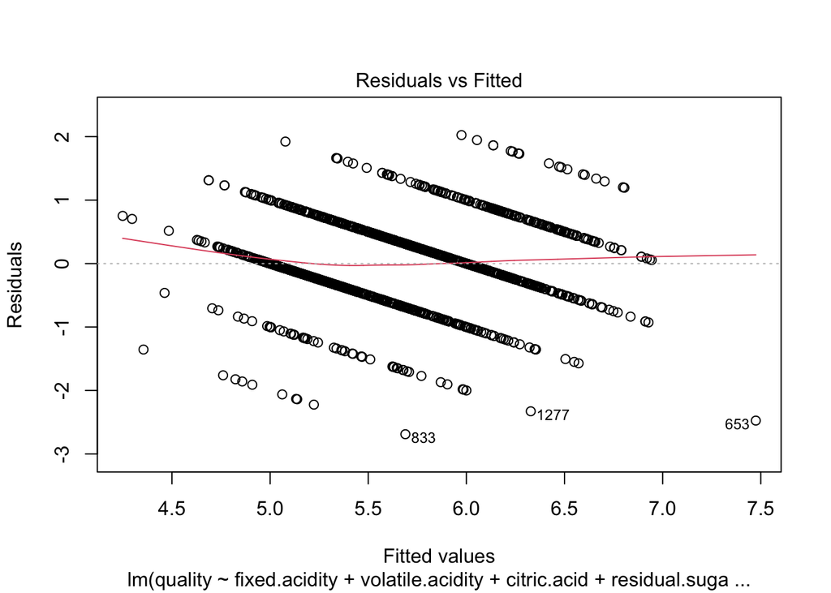

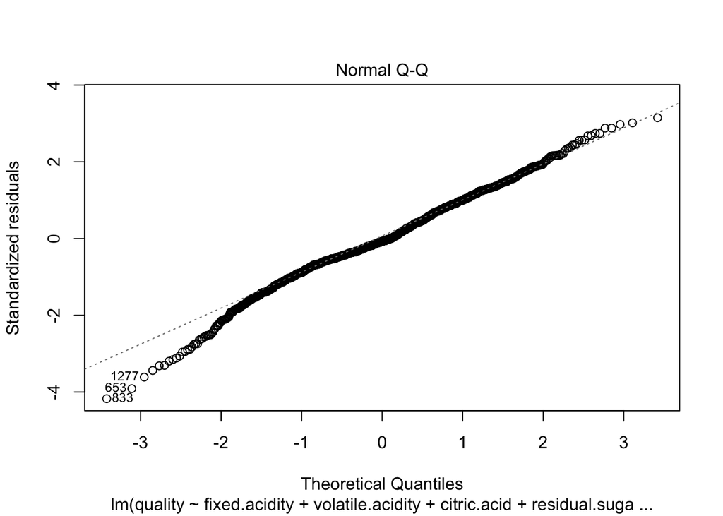

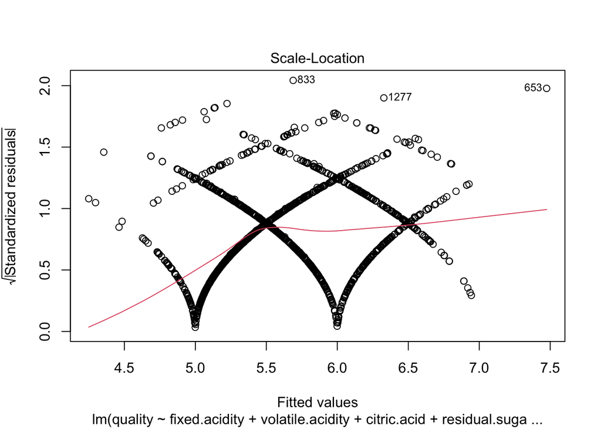

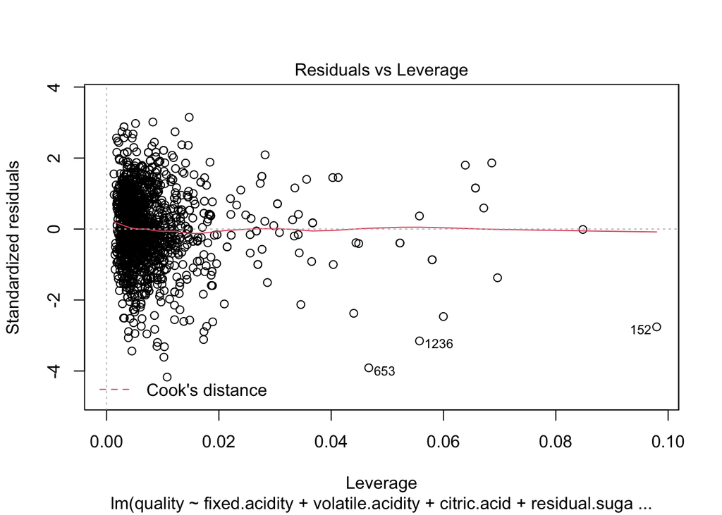

```r
plot(modelo)
```

Se aprecia que afectan significativamente en la calidad los atributos: **volatile.acidity, chlorides, total.sulfur.dioxide, sulphates y alcohol**. Con una significatividad más baja afectan el free.sulfur.dioxide y el pH. Pese a ello, comprobamos en R-squared que el modelo solo es útil para un 36% de las muestras.

De esta manera, generamos un conjunto de datos sin los outliers para comprobar si podemos encontrar un modelo mejor al anterior:

```r
datos_limpios <- wines[-c(which(wines$fixed.acidity %in% c(boxplot.stats(wines$fixed.acidity)$out)),which(wines$volatile.acidity %in% c(boxplot.stats(wines$volatile.acidity)$out)),which(wines$citric.acid %in% c(boxplot.stats(wines$citric.acid)$out)),which(wines$residual.sugar %in% c(boxplot.stats(wines$residual.sugar)$out)),which(wines$chlorides %in% c(boxplot.stats(wines$chlorides)$out)),which(wines$free.sulfur.dioxide %in% c(boxplot.stats(wines$free.sulfur.dioxide)$out)),which(wines$total.sulfur.dioxide %in% c(boxplot.stats(wines$total.sulfur.dioxide)$out)),which(wines$density %in% c(boxplot.stats(wines$density)$out)),which(wines$pH %in% c(boxplot.stats(wines$pH)$out)),which(wines$sulphates %in% c(boxplot.stats(wines$sulphates)$out)),which(wines$alcohol %in% c(boxplot.stats(wines$alcohol)$out))), ]
dim(datos_limpios)
```

```
## [1] 1194   13
```

```r
modelo2 <- lm(quality ~ fixed.acidity + volatile.acidity + citric.acid + residual.sugar + chlorides + free.sulfur.dioxide + total.sulfur.dioxide + density + pH + sulphates + alcohol, data = datos_limpios)
summary(modelo2)
```

```
##
## Call:
## lm(formula = quality ~ fixed.acidity + volatile.acidity + citric.acid +
##     residual.sugar + chlorides + free.sulfur.dioxide + total.sulfur.dioxide +
##     density + pH + sulphates + alcohol, data = datos_limpios)
##
## Residuals:
##      Min       1Q   Median       3Q      Max
## -2.26580 -0.36791 -0.04936  0.41792  1.89284
##
## Coefficients:
##                        Estimate Std. Error t value Pr(>|t|)
## (Intercept)           2.684e+01  2.748e+01   0.977  0.32893
## fixed.acidity         1.898e-02  3.100e-02   0.612  0.54061
## volatile.acidity     -8.504e-01  1.503e-01  -5.660  1.9e-08 ***
## citric.acid          -3.136e-01  1.708e-01  -1.836  0.06664 .
## residual.sugar        1.238e-02  5.152e-02   0.240  0.81012
## chlorides            -1.444e+00  1.383e+00  -1.044  0.29675
## free.sulfur.dioxide   3.921e-03  2.653e-03   1.478  0.13972
## total.sulfur.dioxide -2.639e-03  9.512e-04  -2.774  0.00563 **
## density              -2.272e+01  2.804e+01  -0.810  0.41799
## pH                   -6.461e-01  2.312e-01  -2.795  0.00528 **
## sulphates             1.735e+00  1.721e-01  10.079  < 2e-16 ***
## alcohol               2.894e-01  3.401e-02   8.511  < 2e-16 ***
## ---
## Signif. codes:  0 '***' 0.001 '**' 0.01 '*' 0.05 '.' 0.1 ' ' 1
##
## Residual standard error: 0.6002 on 1182 degrees of freedom
## Multiple R-squared:  0.3925, Adjusted R-squared:  0.3869
## F-statistic: 69.43 on 11 and 1182 DF,  p-value: < 2.2e-16
```

El resultado mejora en un 3% respecto al modelo con los outliers y supone una gran diferencia en los atributos que influyen significativamente en la calidad. En este caso, tendríamos que volatile.acidity, sulphates y alcohol tienen una significancia alta en la calidad del vino, el total.sulfur.dioxide y el pH una significancia media y citric.acid una significancia baja.

Aún así, consideramos que la mejora es demasiado baja teniendo en cuenta que produce una eliminación de 400 muestras, lo que supone un 25% del total. Por lo tanto, optamos por considerar más consistente el modelo anterior.

Antes de concluir qué propiedades son más determinantes para que el vino sea bueno, revisamos la cantidad de muestras de vinos buenos y no buenos de los que disponemos:

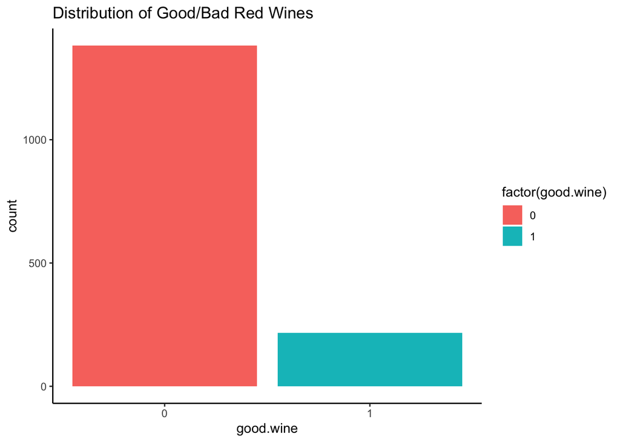

```r
ggplot(wines,aes(x=good.wine,fill=factor(good.wine)))+geom_bar(stat = "count",position = "dodge")+
  scale_x_continuous(breaks = seq(0,1,1))+
  ggtitle("Distribution of Good/Bad Red Wines") +
  theme_classic()
```

Podemos observar que la diferencia entre los dos grupos es muy notable. Sabiendo este dato, podemos esperar que el cálculo con randomForest sea bastante más preciso para el grupo de “no buenos”. Revisamos los resultados:

```r
winesRF <- randomForest(factor(good.wine)~.-quality,wines,ntree=150)
winesRF
```

```
##
## Call:
##  randomForest(formula = factor(good.wine) ~ . - quality, data = wines,      ntree = 150)
##                Type of random forest: classification
##                      Number of trees: 150
## No. of variables tried at each split: 3
##
##         OOB estimate of  error rate: 8.82%
## Confusion matrix:
##      0   1 class.error
## 0 1344  38  0.02749638
## 1  103 114  0.47465438
```

Finalmente, procedemos a revisar las variables que más influyen en que el vino sea bueno:

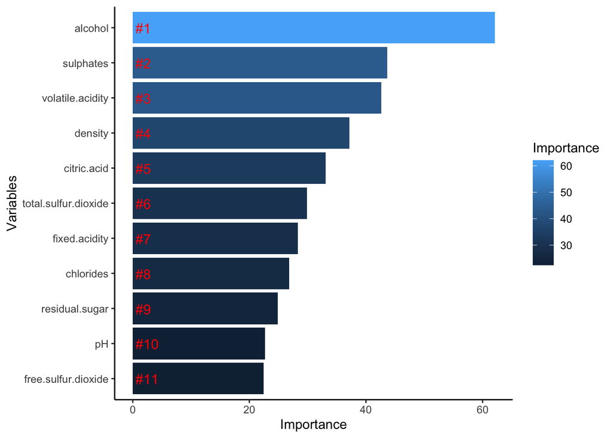

```r
importance <- importance(winesRF)
varImportance <- data.frame(Variables = row.names(importance), Importance = round(importance[,'MeanDecreaseGini'],2))
rankImportance <- varImportance %>% mutate(Rank = paste0('#',dense_rank(desc(Importance)))) # Crear una variable de rango basada en la importancia
ggplot(rankImportance, aes(x = reorder(Variables, Importance), y = Importance, fill = Importance)) +
  geom_bar(stat='identity') +
  geom_text(aes(x = Variables, y = 0.5, label = Rank), hjust=0, vjust=0.55, size = 4, colour = 'red') +
  labs(x = 'Variables') +
  coord_flip() +
  theme_classic()
```

Observamos en los resultados que el atributo que más influye en la calidad del vino es el alcohol, seguido de los sulfatos y de la volatilidad de la acidez.

Extraemos el conjunto de datos final en un excel:

```r
write_xlsx(wines, path="winequality-red-final.xlsx", col_names = TRUE)
```

# 6 Resolución del problema. A partir de los resultados obtenidos, ¿cuáles son las conclusiones? ¿Los resultados permiten responder al problema?

El objetivo del análisis del conjunto de datos sobre los atributos del vino y su calidad era conocer qué propiedades afectaban más en la calidad del vino y en considerar a un vino como bueno.

Pese a ello, hemos obtenido los siguientes resultados:

Por lo tanto, hemos llegado a darnos cuenta de que **las propiedades más importantes en la determinación de la calidad del vino son el alcohol, los sulfatos y la volatilidad de la acidez**.

# 7 Tabla de contribuciones

| Contribuciones | Firma |
| --- | --- |
| Investigación previa | M.C y J.P |
| Redacción de las respuestas | M.C y J.P |
| Desarrollo código | M.C y J.P |

# Bibliografía

[1]

C. Cortez Paulo, “Wine Quality.” UCI Machine Learning Repository, 2009. Available: https://archive-beta.ics.uci.edu/ml/datasets/wine+quality

[2]

M. C. G. Laia Subirats Maté Diego Oswaldo Pérez Trenard, “Introducción a la limpieza y el análisis de los datos.” Universitat Oberta de Catalunya.